# OncoSimulR: forward genetic simulation in asexual populations with arbitrary epistatic interactions and a focus on modeling tumor progression.

### 5.2.2 Example 1.b

This is a specific case of synthetic viability (see also section 3.9):

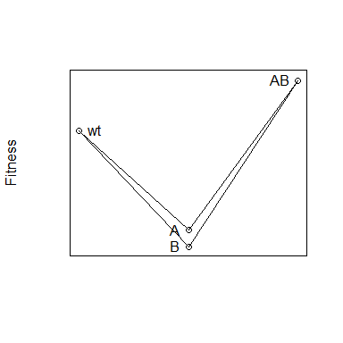

Here, $S_A, S_B < 0$, $S_B < 0$, $S_{AB} > 0$ and $(1 + S_{AB}) (1 + S_A) (1 + S_B) > 1$.

As before, we can specify this in several different ways. The simplest is to specify all genotypes:

```r
sa <- -0.6
sb <- -0.7
sab <- 0.3
m1b1 <- allFitnessEffects(epistasis = c("A:-B" = sa,
                                        "-A:B" = sb,
                                        "A:B" = sab))
evalAllGenotypes(m1b1, order = FALSE, addwt = TRUE)
##   Genotype Fitness
## 1       WT     1.0
## 2        A     0.4
## 3        B     0.3
## 4     A, B     1.3
```

We could also use a tree and modify the “sab” for the epistasis, as before (5.2.1).

### 5.2.3 Example 1.c

The final case, in figure 1.c of Misra et al., is just epistasis, where a mutation in one of the genes is deleterious (possibly only mildly), in the other is beneficial, and the double mutation has fitness larger than any of the other two.

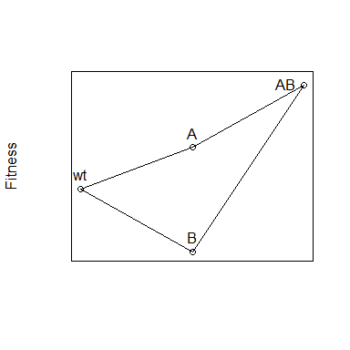

As before, we can specify this in several different ways. The simplest is to specify all genotypes:

```r
sa <- 0.2
sb <- -0.3
sab <- 0.5
m1c1 <- allFitnessEffects(epistasis = c("A:-B" = sa,
                                        "-A:B" = sb,
                                        "A:B" = sab))
evalAllGenotypes(m1c1, order = FALSE, addwt = TRUE)
##   Genotype Fitness
## 1       WT     1.0
## 2        A     1.2
## 3        B     0.7
## 4     A, B     1.5
```

We could also use a tree and modify the “sab” for the epistasis, as before (5.2.1).

## 5.3 Ochs and Desai, 2015

In Ochs and Desai (2015) the authors present a model shown graphically as (the actual numerical values are arbitrarily set by me):

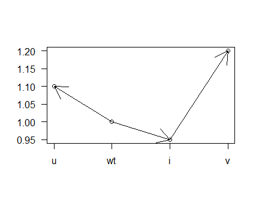

In their model, $s_u > 0$, $s_v > s_u$, $s_i < 0$, we can only arrive at $v$ from $i$, and the mutants “ui” and “uv” can never appear as their fitness is 0, or $-\infty$, so $s_{ui} = s_{uv} = -1$ (or $-\infty$).

We can specify this combining a graph and epistasis specifications:

```r
su <- 0.1
si <- -0.05
fvi <- 1.2 ## the fitness of the vi mutant
sv <- (fvi/(1 + si)) - 1
sui <- suv <- -1
od <- allFitnessEffects(
    data.frame(parent = c("Root", "Root", "i"),
               child = c("u", "i", "v"),
               s = c(su, si, sv),
               sh = -1,
               typeDep = "MN"),
    epistasis = c(
        "u:i" = sui,
        "u:v" = suv))
```

A figure showing that model is

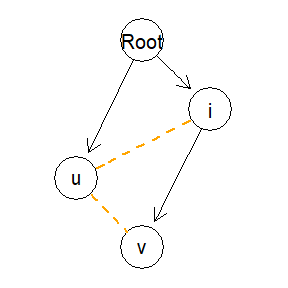

```r
plot(od)
```

And the fitness of all genotype is

```r
evalAllGenotypes(od, order = FALSE, addwt = TRUE)
##   Genotype Fitness
## 1       WT    1.00
## 2        i    0.95
## 3        u    1.10
## 4        v    0.00
## 5     i, u    0.00
## 6     i, v    1.20
## 7     u, v    0.00
## 8  i, u, v    0.00
```

We could alternatively have specified fitness either directly specifying the fitness of each genotype or specifying epistatic effects. Let us use the second approach:

```r
u <- 0.1; i <- -0.05; vi <- (1.2/0.95) - 1; ui <- uv <- -Inf
od2 <- allFitnessEffects(
    epistasis = c("u" = u,  "u:i" = ui,
                  "u:v" = uv, "i" = i,
                  "v:-i" = -Inf, "v:i" = vi))
evalAllGenotypes(od2, addwt = TRUE)
##   Genotype Fitness
## 1       WT    1.00
## 2        i    0.95
## 3        u    1.10
## 4        v    0.00
## 5     i, u    0.00
## 6     i, v    1.20
## 7     u, v    0.00
## 8  i, u, v    0.00
```

We will return to this model when we explain the usage of `fixation` for stopping the simulations (see 6.3.3 and 6.3.4).

## 5.4 Weissman et al., 2009

In their figure 1a, Weissman et al. (2009) present this model (actual numeric values are set arbitrarily)

### 5.4.1 Figure 1.a

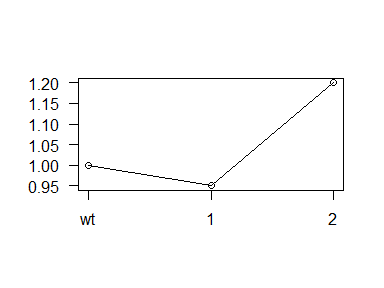

where the “1” and “2” in the figure refer to the total number of mutations in two different loci. This is, therefore, very similar to the example in section 5.2.2. Here we have, in their notation, $\delta_1 < 0$, fitness of single “A” or single “B” = $1 + \delta_1$, $S_{AB} > 0$, $(1 + S_{AB})(1 + \delta_1)^2 > 1$.

### 5.4.2 Figure 1.b

In their figure 1b they show

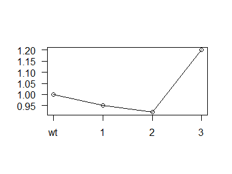

Where, as before, 1, 2, 3, denote the total number of mutations over three different loci and $\delta_1 < 0$, $\delta_2 < 0$, fitness of single mutant is $(1 + \delta_1)$, of double mutant is $(1 + \delta_2)$ so that $(1 + \delta_2) = (1 + \delta_1)^2 (1 + s_2)$ and of triple mutant is $(1 + \delta_3)$, so that $(1 + \delta_3) = (1 + \delta_1)^3 (1 + s_2)^3 (1 + s_3)$.

We can specify this combining a graph with epistasis:

```r
d1 <- -0.05 ## single mutant fitness 0.95
d2 <- -0.08 ## double mutant fitness 0.92
d3 <- 0.2   ## triple mutant fitness 1.2

s2 <- ((1 + d2)/(1 + d1)^2) - 1
s3 <- ( (1 + d3)/((1 + d1)^3 * (1 + s2)^3) ) - 1

w <- allFitnessEffects(
    data.frame(parent = c("Root", "Root", "Root"),
               child = c("A", "B", "C"),
               s = d1,
               sh = -1,
               typeDep = "MN"),
    epistasis = c(
        "A:B" = s2,
        "A:C" = s2,
        "B:C" = s2,
        "A:B:C" = s3))
```

The model can be shown graphically as:

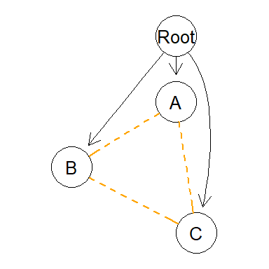

```r
plot(w)
```

And fitness of all genotypes is:

```r
evalAllGenotypes(w, order = FALSE, addwt = TRUE)
##   Genotype Fitness
## 1       WT    1.00
## 2        A    0.95
## 3        B    0.95
## 4        C    0.95
## 5     A, B    0.92
## 6     A, C    0.92
## 7     B, C    0.92
## 8  A, B, C    1.20
```

Alternatively, we can directly specify what each genotype adds to the fitness, given the included genotype. This is basically replacing the graph by giving each of “A”, “B”, and “C” directly:

```r
wb <- allFitnessEffects(
    epistasis = c(
        "A" = d1,
        "B" = d1,
        "C" = d1,
        "A:B" = s2,
        "A:C" = s2,
        "B:C" = s2,
        "A:B:C" = s3))

evalAllGenotypes(wb, order = FALSE, addwt = TRUE)
##   Genotype Fitness
## 1       WT    1.00
## 2        A    0.95
## 3        B    0.95
## 4        C    0.95
## 5     A, B    0.92
## 6     A, C    0.92
## 7     B, C    0.92
## 8  A, B, C    1.20
```

The plot, of course, is not very revealing and we cannot show that there is a three-way interaction (only all three two-way interactions):

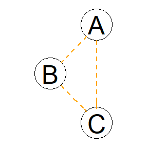

```r
plot(wb)
```

As we have seen several times already (sections 3.7.1, 3.7.2, 3.7.3) we can also give the genotypes directly and, consequently, the fitness of each genotype (not the added contribution):

```r
wc <- allFitnessEffects(
    epistasis = c(
        "A:-B:-C" = d1,
        "B:-C:-A" = d1,
        "C:-A:-B" = d1,
        "A:B:-C" = d2,
        "A:C:-B" = d2,
        "B:C:-A" = d2,
        "A:B:C" = d3))
evalAllGenotypes(wc, order = FALSE, addwt = TRUE)
##   Genotype Fitness
## 1       WT    1.00
## 2        A    0.95
## 3        B    0.95
## 4        C    0.95
## 5     A, B    0.92
## 6     A, C    0.92
## 7     B, C    0.92
## 8  A, B, C    1.20
```

## 5.5 Gerstung et al., 2011, pancreatic cancer poset

We can specify the pancreatic cancer poset in Gerstung et al. (2011) (their figure 2B, left). We use directly the names of the genes, since that is immediately supported by the new version.

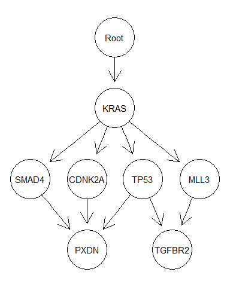

```r
pancr <- allFitnessEffects(
    data.frame(parent = c("Root", rep("KRAS", 4),
                   "SMAD4", "CDNK2A",
                   "TP53", "TP53", "MLL3"),
               child = c("KRAS","SMAD4", "CDNK2A",
                   "TP53", "MLL3",
                   rep("PXDN", 3), rep("TGFBR2", 2)),
               s = 0.1,
               sh = -0.9,
               typeDep = "MN"))

plot(pancr)
```

Of course the “s” and “sh” are set arbitrarily here.

## 5.6 Raphael and Vandin’s 2014 modules

In Raphael and Vandin (2015), the authors show several progression models in terms of modules. We can code the extended poset for the colorectal cancer model in their Figure 4.a is (s and sh are arbitrary):

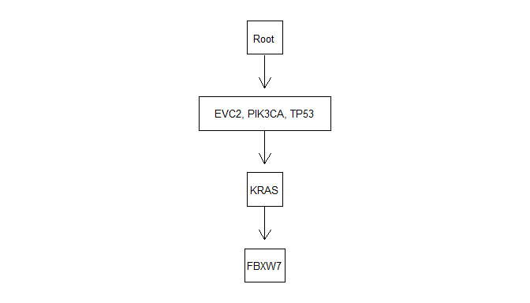

```r
rv1 <- allFitnessEffects(data.frame(parent = c("Root", "A", "KRAS"),
                                    child = c("A", "KRAS", "FBXW7"),
                                    s = 0.1,
                                    sh = -0.01,
                                    typeDep = "MN"),
                         geneToModule = c("Root" = "Root",
                             "A" = "EVC2, PIK3CA, TP53",
                             "KRAS" = "KRAS",
                             "FBXW7" = "FBXW7"))

plot(rv1, expandModules = TRUE, autofit = TRUE)
```

We have used the (experimental) `autofit` option to fit the labels to the edges. Note how we can use the same name for genes and modules, but we need to specify all the modules.

Their Figure 5b is

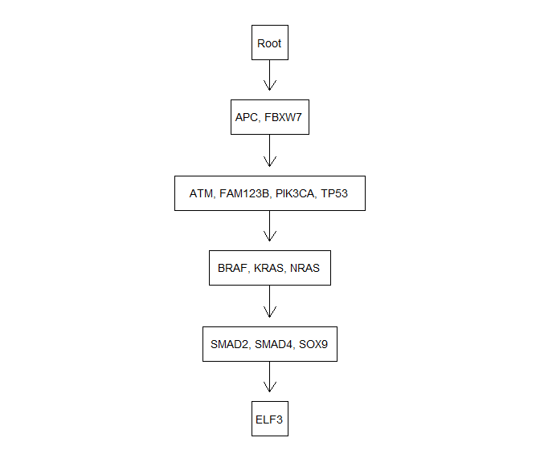

```r
rv2 <- allFitnessEffects(
    data.frame(parent = c("Root", "1", "2", "3", "4"),
               child = c("1", "2", "3", "4", "ELF3"),
               s = 0.1,
               sh = -0.01,
               typeDep = "MN"),
    geneToModule = c("Root" = "Root",
                     "1" = "APC, FBXW7",
                     "2" = "ATM, FAM123B, PIK3CA, TP53",
                     "3" = "BRAF, KRAS, NRAS",
                     "4" = "SMAD2, SMAD4, SOX9",
                     "ELF3" = "ELF3"))

plot(rv2, expandModules = TRUE,   autofit = TRUE)
```

# 6 Running and plotting the simulations: starting, ending, and examples

## 6.1 Starting and ending

After you have decided the specifics of the fitness effects and the model, you need to decide:

- Where will you start your simulation from. This involves deciding the initial population size (argument `initSize`) and, possibly, the genotype of the initial population; the later is covered in section 6.2.
- When will you stop it: how long to run it, and whether or not to require simulations to reach cancer (under some definition of what it means to reach cancer). This is covered in 6.3.

## 6.2 Can I start the simulation from a specific mutant?

You bet. In version 2 you can specify the genotype for the initial mutant with the same flexibility as in `evalGenotype`. Here we show a couple of examples (we use the representation of the parent-child relationships —discussed in section 8— of the clones so that you can see which clones appear, and from which, and check that we are not making mistakes).

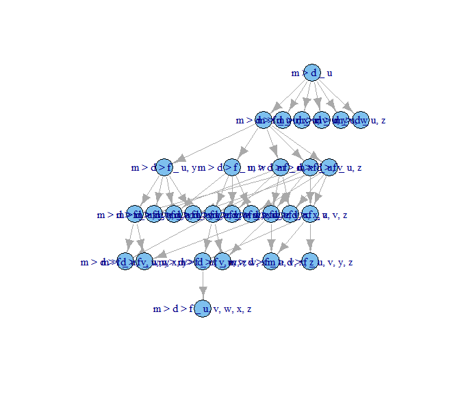

```r
o3init <- allFitnessEffects(orderEffects = c(
                            "M > D > F" = 0.99,
                            "D > M > F" = 0.2,
                            "D > M"     = 0.1,
                            "M > D"     = 0.9),
                        noIntGenes = c("u" = 0.01,
                                       "v" = 0.01,
                                       "w" = 0.001,
                                       "x" = 0.0001,
                                       "y" = -0.0001,
                                       "z" = -0.001),
                        geneToModule =
                            c("M" = "m",
                              "F" = "f",
                              "D" = "d") )

oneI <- oncoSimulIndiv(o3init, model = "McFL",
                       mu = 5e-5, finalTime = 200,
                       detectionDrivers = 3,
                       onlyCancer = FALSE,
                       initSize = 1000,
                       keepPhylog = TRUE,
                       initMutant = c("m > u > d")
                       )
plotClonePhylog(oneI, N = 0)
```

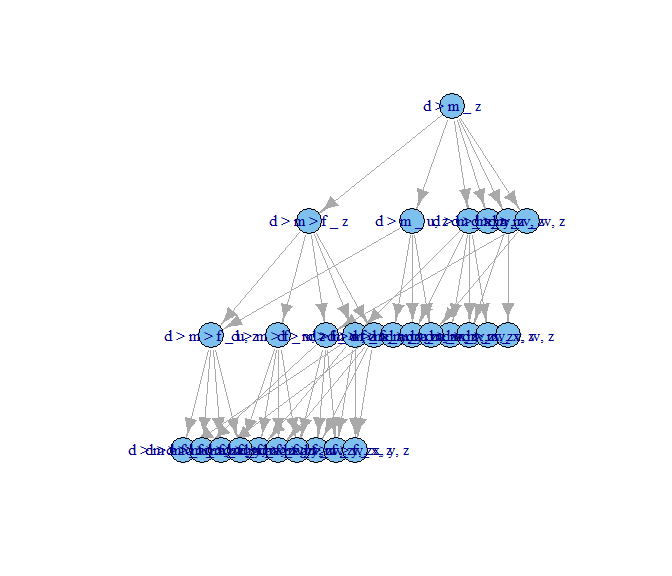

```r
## Note we also disable the stopping stochastically as a function of size
## to allow the population to grow large and generate may different
## clones.

## For speed, we set a small finalTime and we fix the seed
## for reproducilibity. Beware: since finalTime is short, sometimes
## we do not reach cancer
set.seed(1)
RNGkind("L'Ecuyer-CMRG")

ospI <- oncoSimulPop(2,
                    o3init, model = "Exp",
                    mu = 5e-5, finalTime = 200,
                    detectionDrivers = 3,
                    onlyCancer = TRUE,
                    initSize = 10,
                    keepPhylog = TRUE,
                    initMutant = c("d > m > z"),
                    mc.cores = 2,
                    seed = NULL
                    )
## You are running Windows. Setting mc.cores = 1

## Show just one example
## op <- par(mar = rep(0, 4), mfrow = c(1, 2))
plotClonePhylog(ospI[[1]])
```

```r
## plotClonePhylog(ospI[[2]])
## par(op)

set.seed(1)
RNGkind("L'Ecuyer-CMRG")
ossI <- oncoSimulSample(2,
                        o3init, model = "Exp",
                        mu = 5e-5, finalTime = 200,
                        detectionDrivers = 2,
                        onlyCancer = TRUE,
                        initSize = 10,
                        initMutant = c("z > d"),
                        ## check presence of initMutant:
                        thresholdWhole = 1,
                        seed = NULL
                    )
## Successfully sampled 2 individuals
##
##  Subjects by Genes matrix of 2 subjects and 9 genes.

## No phylogeny is kept with oncoSimulSample, but look at the
## OcurringDrivers and the sample
ossI$popSample
##      d f m u v w x y z
## [1,] 1 0 1 0 0 0 0 0 1
## [2,] 1 0 1 0 0 0 0 0 1
ossI$popSummary[, "OccurringDrivers", drop = FALSE]
##   OccurringDrivers
## 1
## 2
```

Since version 2.21.994, it is possible to start the simulations from arbitrary initial configurations: this uses multiple initial mutants (see section 6.7) and allows for multispecies simulations (section 6.8).

## 6.3 Ending the simulations

OncoSimulR provides very flexible ways to decide when to stop a simulation. Here we focus on a single simulation; see further options with multiple simulations in 7.

### 6.3.1 Ending the simulations: conditions

- **`onlyCancer = TRUE`**. A simulation will be repeated until any one of the “reach cancer” conditions is met, if this happens before the simulation reaches `finalTime`[^11]. These conditions are:
  - Total population size becomes larger than `detectionSize`.
  - The number of drivers in any one genotype or clone becomes equal to, or larger than, `detectionDrivers`; note that this allows you to stop the simulation as soon as a **specific genotype** is found, by using exactly and only the genes that make that genotype as the drivers. This is not allowed by the moment in frequency-dependent fitness simulations.
  - A gene or gene combination among those listed in `fixation` becomes fixed in the population (i.e., has a frequency is 1) (see details in (6.3.3 and 6.3.4).
  - The tumor is detected according to a stochastic detection mechanism, where the probability of “detecting the tumor” increases with population size; this is explained below (6.3.2) and is controlled by argument `detectionProb`.

  As we exit as soon as any of the exiting conditions is reached, if you only care about one condition, set the other to `NA` (see also section 6.3.2.1).
- **`onlyCancer = FALSE`**. A simulation will run only once, and will exit as soon as any of the above conditions are met or as soon as the total population size becomes zero or we reach `finalTime`.

In the `onlyCancer = TRUE` case, what happens if we reach `finalTime` (or the population size becomes zero) before any of the “reach cancer” conditions have been fulfilled? The simulation will be repeated again, within the following limits:

- `max.wall.time`: the total wall time we allow an individual simulation to run;
- `max.num.tries`: the maximum number of times we allow a simulation to be repeated to reach cancer;
- `max.wall.time.total` and `max.num.tries.total`, similar to the above but over a set of simulations in function `oncoSimulSample`.

Incidentally, we keep track of the number of attempts used (the component `other$attemptsUsed$`) before we reach cancer, so you can estimate (as from a negative binomial sampling) the probability of reaching your desired end point under different scenarios.

The `onlyCancer = FALSE` case might be what you want to do when you examine general population genetics scenarios without focusing on possible sampling issues. To do this, set `finalTime` to the value you want and set `onlyCancer = FALSE`; in addition, set `detectionProb` to “NA” and `detectionDrivers` and `detectionSize` to “NA” or to huge numbers[^12]. In this scenario you simply collect the simulation output at the end of the run, regardless of what happened with the population (it became extinct, it did not reach a large size, it did not accumulate drivers, etc).

### 6.3.2 Stochastic detection mechanism: “detectionProb”

This is the process that is controlled by the argument `detectionProb`. Here the probability of tumor detection increases with the total population size. This is biologically a reasonable assumption: the larger the tumor, the more likely it is it will be detected.

At regularly spaced times during the simulation, we compute the probability of detection as a function of size and determine (by comparing against a random uniform number) if the simulation should finish. For simplicity, and to make sure the probability is bounded between 0 and 1, we use the function

$$\begin{equation}
P(N) =
\begin{cases}
1 - e^{ -c ( (N - B)/B)} & \text{if } N > B \\
0 & \text{if } N \leq B
\end{cases}
\label{eq:2}
\end{equation}$$

where $P(N)$ is the probability that a tumor with a population size $N$ will be detected, and $c$ (argument $cPDetect$ in the `oncoSimul*` functions) controls how fast $P(N)$ increases with increasing population size relative to a baseline, $B$ ($PDBaseline$ in the `oncoSimul*` functions); with $B$ we both control the minimal population size at which this mechanism stats operating (because we will rarely want detection unless there is some meaningful increase of population size over `initSize`) and we model the increase in $P(N)$ as a function of relative differences with respect to $B$. (Note that this is **a major change** in version 2.9.9. Before version 2.9.9, the expression used was $P(N) = 1 - e^{ -c ( N - B)}$, so we did not make the increase relative to $B$; of course, you can choose an appropriate $c$ to make different models comparable, but the expression used before 2.9.9 made it much harder to compare simulations with very different initial population sizes, as baselines are often naturall a function of initial population sizes.)

The $P(N)$ refers to the probability of detection at each one of the occasions when we assess the probability of exiting. When, or how often, do we do that? When we assess probability of exiting is controlled by `checkSizePEvery`, which will often be much larger than `sampleEvery`[^13]. Biologically, a way to think of `checkSizePEvery` is “time between doctor appointments”.

An important **warning**, though: for populations that are growing very, very fast or where some genes might have very large effects on fitness even a moderate `checkSizePEvery` of, say, 10, might be inappropriate, since populations could have increased by several orders of magnitude between successive checks. This issue is also discussed in section 2.1.1 and 2.2.

Finally, you can specify $c$ ($cPDetect$) directly (you will need to set `n2` and `p2` to NA). However, it might be more intuitive to specify the pair `n2`, `p2`, such that $P(n2) = p2$ (and from that pair we solve for the value of $cPDetect$).

You can get a feeling for the effects of these arguments by playing with the following code, that we do not execute here for the sake of speed. Here no mutation has any effect, but there is a non-zero probability of exiting as soon as the total population size becomes larger than the initial population size. So, eventually, all simulations will exit and, as we are using the McFarland model, population size will vary slightly around the initial population size.

```r
gi2 <- rep(0, 5)
names(gi2) <- letters[1:5]
oi2 <- allFitnessEffects(noIntGenes = gi2)
s5 <- oncoSimulPop(200,
                   oi2,
                   model = "McFL",
                   initSize = 1000,
                   detectionProb = c(p2 = 0.1,
                                     n2 = 2000,
                                     PDBaseline = 1000,
                                     checkSizePEvery = 2),
                   detectionSize = NA,
                   finalTime = NA,
                   keepEvery = NA,
                   detectionDrivers = NA)
s5
hist(unlist(lapply(s5, function(x) x$FinalTime)))
```

As you decrease `checkSizePEvery` the distribution of “FinalTime” will resemble more and more an exponential distribution.

In this vignette, there are some further examples of using this mechanism in 6.5.4 and 6.5.2, with the default arguments.

#### 6.3.2.1 Stochastic detection mechanism and minimum number of drivers

We said above that we exit as soon as any of the conditions is reached (i.e., we use an OR operation over the exit conditions). There is a special exception to this procedure: if you set `AND_DrvProbExit = TRUE`, both the number of drivers and the `detectionProb` mechanism condition must fulfilled. This means that the `detectionProb` mechanism not assessed unless the `detectionDrivers` condition is. Using `AND_DrvProbExit = TRUE` allows to run simulations and ensure that all of the returned simulations will have at least some cells with the number of drivers as specified by `detectionDrivers`. Note, though, that this does not guarantee that when you sample the population, all those drivers will be detected (as this depends on the actual proportion of cells with the drivers and the settings of `samplePop`).

### 6.3.3 Fixation of genes/gene combinations

In some cases we might be interested in running simulations until a particular set of genes, or gene combinations, reaches fixation. This exit condition might be more relevant than some of the above in many non-cancer-related evolutionary genetics scenarios.

Simulations will stop as soon as any of the genes or gene combinations in the vector (or list) `fixation` reaches a frequency of 1. These gene combinations might have non-zero intersection (i.e., they might share genes), and those genes need not be drivers. If we want simulations to only stop when fixation of those genes/gene combinations is reached, we will set all other stopping conditions to `NA`. It is, of course, up to you to ensure that those stopping conditions are reasonable (that they can be reached) and to use, or not, `finalTime`; otherwise, simulations will eventually abort (e.g., when `max.wall.time` or `max.num.tries` are reached). Since we are asking for fixation, the `Exp` or `Bozic` models will often not be appropriate here; instead, models with competition such as `McFL` are more appropriate.

We return here to the example from section 5.3.

```r
u <- 0.2; i <- -0.02; vi <- 0.6; ui <- uv <- -Inf
od2 <- allFitnessEffects(
    epistasis = c("u" = u,  "u:i" = ui,
                  "u:v" = uv, "i" = i,
                  "v:-i" = -Inf, "v:i" = vi))
```

Ochs and Desai explain that “Each simulated population was evolved until either the uphill genotype or valley-crossing genotype fixed.” (see Ochs and Desai (2015), p.2, section “Simulations”). We will do the same here. We specify that we want to end the simulation when either the “u” or the “v, i” genotypes have reached fixation, by passing those genotype combinations as the `fixation` argument (in this example using `fixation = c("u", "v")` would have been equivalent, since the “v” genotype by itself has fitness of 0).

We want to be explicit that fixation will be the one and only condition for ending the simulations, and thus we set arguments `detectionDrivers`, `finalTime`, `detectionSize` and `detectionProb` explicitly to `NA`. (We set the number of repetitions only to 10 for the sake of speed when creating the vignette).

```r
initS <- 20
## We use only a small number of repetitions for the sake
## of speed. Even fewer in Windows, since we run on a single
## core

if(.Platform$OS.type == "windows") {
    nruns <- 4
} else {
    nruns <- 10
}

od100 <- oncoSimulPop(nruns, od2,
                      fixation = c("u", "v, i"),
                      model = "McFL",
                      mu = 1e-4,
                      detectionDrivers = NA,
                      finalTime = NA,
                      detectionSize = NA,
                      detectionProb = NA,
                      onlyCancer = TRUE,
                      initSize = initS,
                      mc.cores = 2)
## You are running Windows. Setting mc.cores = 1
```

What is the frequency of each genotype among the simulations? (or, what is the frequency of fixation of each genotype?)

```r
sampledGenotypes(samplePop(od100))
##
##  Subjects by Genes matrix of 4 subjects and 3 genes.
##   Genotype Freq
## 1        u    4
##
##  Shannon's diversity (entropy) of sampled genotypes: 0
```

Note the very large variability in reaching fixation

```r
head(summary(od100)[, c(1:3, 8:9)])
##   NumClones TotalPopSize LargestClone FinalTime NumIter
## 1         3           32           32  4277.400  171116
## 2         2           23           23   352.200   14090
## 3         3           40           40  4287.025  171495
## 4         2           22           22    88.750    3551
```

### 6.3.4 Fixation of genotypes

Section 6.3.3 deals with the fixation of gene/gene combinations. What if you want fixation on specific genotypes? To give an example, suppose we have a five loci genotype and suppose that you want to stop the simulations only if genotypes “A”, “B, E”, or “A, B, C, D, E” reach fixation. You do not want to stop it if, say, genotype “A, B, E” reaches fixation. To specify genotypes, you prepend the genotype combinations with a "_,", and that tells OncoSimulR that you want fixation of **genotypes**, not just gene combinations.

An example of the differences between the mechanisms can be seen from this code:

```r
## Create a simple fitness landscape
rl1 <- matrix(0, ncol = 6, nrow = 9)
colnames(rl1) <- c(LETTERS[1:5], "Fitness")
rl1[1, 6] <- 1
rl1[cbind((2:4), c(1:3))] <- 1
rl1[2, 6] <- 1.4
rl1[3, 6] <- 1.32
rl1[4, 6] <- 1.32
rl1[5, ] <- c(0, 1, 0, 0, 1, 1.5)
rl1[6, ] <- c(0, 0, 1, 1, 0, 1.54)
rl1[7, ] <- c(1, 0, 1, 1, 0, 1.65)
rl1[8, ] <- c(1, 1, 1, 1, 0, 1.75)
rl1[9, ] <- c(1, 1, 1, 1, 1, 1.85)
class(rl1) <- c("matrix", "genotype_fitness_matrix")
## plot(rl1) ## to see the fitness landscape

## Gene combinations
local_max_g <- c("A", "B, E", "A, B, C, D, E")
## Specify the genotypes
local_max <- paste0("_,", local_max_g)

fr1 <- allFitnessEffects(genotFitness = rl1, drvNames = LETTERS[1:5])
initS <- 2000


######## Stop on gene combinations   #####
r1 <- oncoSimulPop(10,
                       fp = fr1,
                       model = "McFL",
                       initSize = initS,
                       mu = 1e-4,
                       detectionSize = NA,
                       sampleEvery = .03,
                       keepEvery = 1,
                       finalTime = 50000,
                       fixation = local_max_g,
                       detectionDrivers = NA,
                       detectionProb = NA,
                       onlyCancer = TRUE,
                       max.num.tries = 500,
                       max.wall.time = 20,
                       errorHitMaxTries = TRUE,
                       keepPhylog = FALSE,
                       mc.cores = 2)
## You are running Windows. Setting mc.cores = 1
sp1 <- samplePop(r1, "last", "singleCell")
##
##  Subjects by Genes matrix of 10 subjects and 5 genes.
sgsp1 <- sampledGenotypes(sp1)
## often you will stop on gene combinations that
## are not local maxima in the fitness landscape
sgsp1
##     Genotype Freq
## 1          A    5
## 2 A, B, C, D    2
## 3    A, C, D    3
##
##  Shannon's diversity (entropy) of sampled genotypes: 1.029653
sgsp1$Genotype %in% local_max_g
## [1]  TRUE FALSE FALSE

####### Stop on genotypes   ####

r2 <- oncoSimulPop(10,
                       fp = fr1,
                       model = "McFL",
                       initSize = initS,
                       mu = 1e-4,
                       detectionSize = NA,
                       sampleEvery = .03,
                       keepEvery = 1,
                       finalTime = 50000,
                       fixation = local_max,
                       detectionDrivers = NA,
                       detectionProb = NA,
                       onlyCancer = TRUE,
                       max.num.tries = 500,
                       max.wall.time = 20,
                       errorHitMaxTries = TRUE,
                       keepPhylog = FALSE,
                       mc.cores = 2)
## You are running Windows. Setting mc.cores = 1
## All final genotypes should be local maxima
sp2 <- samplePop(r2, "last", "singleCell")
##
##  Subjects by Genes matrix of 10 subjects and 5 genes.
sgsp2 <- sampledGenotypes(sp2)
sgsp2$Genotype %in% local_max_g
## [1] TRUE TRUE TRUE
```

### 6.3.5 Fixation: tolerance, number of periods, minimal size

In particular if you specify stopping on genotypes, you might want to think about three additional parameters: `fixation_tolerance`, `min_successive_fixation`, and `fixation_min_size`.

`fixation_tolerance`: fixation is considered to have happened if the genotype/gene combinations specified as genotypes/gene combinations for fixation have reached a frequency $> 1 - fixation\_tolerance$. (The default is 0, so we ask for genotypes/gene combinations with a frequency of 1, which might not be what you want with large mutation rates and complex fitness landscape with genotypes of similar fitness.)

`min_successive_fixation`: during how many successive sampling periods the conditions of fixation need to be fulfilled before declaring fixation. These must be successive sampling periods without interruptions (i.e., a single period when the condition is not fulfilled will set the counter to 0). This can help to exclude short, transitional, local maxima that are quickly replaced by other genotypes. (The default is 50, but this is probably too small for “real life” usage).

`fixation_min_size`: you might only want to consider fixation to have happened if a minimal size has been reached (this can help weed out local maxima that have fitness that is barely above that of the wild-type genotype). (The default is 0).

An example of using those options:

```r
## Create a simple fitness landscape
rl1 <- matrix(0, ncol = 6, nrow = 9)
colnames(rl1) <- c(LETTERS[1:5], "Fitness")
rl1[1, 6] <- 1
rl1[cbind((2:4), c(1:3))] <- 1
rl1[2, 6] <- 1.4
rl1[3, 6] <- 1.32
rl1[4, 6] <- 1.32
rl1[5, ] <- c(0, 1, 0, 0, 1, 1.5)
rl1[6, ] <- c(0, 0, 1, 1, 0, 1.54)
rl1[7, ] <- c(1, 0, 1, 1, 0, 1.65)
rl1[8, ] <- c(1, 1, 1, 1, 0, 1.75)
rl1[9, ] <- c(1, 1, 1, 1, 1, 1.85)
class(rl1) <- c("matrix", "genotype_fitness_matrix")
## plot(rl1) ## to see the fitness landscape

## The local fitness maxima are
## c("A", "B, E", "A, B, C, D, E")

fr1 <- allFitnessEffects(genotFitness = rl1, drvNames = LETTERS[1:5])
initS <- 2000

## Stop on genotypes

r3 <- oncoSimulPop(10,
                  fp = fr1,
                  model = "McFL",
                  initSize = initS,
                  mu = 1e-4,
                  detectionSize = NA,
                  sampleEvery = .03,
                  keepEvery = 1,
                  finalTime = 50000,
                  fixation = c(paste0("_,",
                                   c("A", "B, E", "A, B, C, D, E")),
                               fixation_tolerance = 0.1,
                               min_successive_fixation = 200,
                               fixation_min_size = 3000),
                  detectionDrivers = NA,
                  detectionProb = NA,
                  onlyCancer = TRUE,
                  max.num.tries = 500,
                  max.wall.time = 20,
                  errorHitMaxTries = TRUE,
                  keepPhylog = FALSE,
                  mc.cores = 2)
## You are running Windows. Setting mc.cores = 1
```

### 6.3.6 Mixing stopping on gene combinations and genotypes

This would probably be awfully confusing and is not tested formally (though it should work). Let me know if you think this is an important feature. (Pull requests with tests welcome.)

## 6.4 Plotting genotype/driver abundance over time; plotting the simulated trajectories

We have seen many of these plots already, starting with Figure 1.2 and Figure 1.4 and we will see many more below, in the examples, starting with section 6.5.1 such as in figures 6.1 and 6.2. In a nutshell, what we are plotting is the information contained in the `pops.by.time` matrix, the matrix that contains the abundances of all the clones (or genotypes) at each of the sampling periods.

The functions that do the work are called `plot` and these are actually methods for objects of class “oncosimul” and “oncosimulpop”. You can access the help by doing `?plot.oncosimul`, for example.

What entities are shown in the plot? You can show the trajectories of:

- numbers of drivers (e.g., 6.1);
- genotypes or clones (e.g., 6.2).

(Of course, showing “drivers” requires that you have specified certain genes as drivers.)

What types of plots are available?

- line plots;
- stacked plots;
- stream plots.

All those three are shown in both of Figure 6.1 and Figure 6.2.

If you run multiple simulations using `oncoSimulPop` you can plot the trajectories of all of the simulations.

## 6.5 Several examples of simulations and plotting simulation trajectories

### 6.5.1 Bauer’s example again

We will use the model of Bauer, Siebert, and Traulsen (2014) that we saw in section 5.1.

```r
K <- 5
sd <- 0.1
sdp <- 0.15
sp <- 0.05
bauer <- data.frame(parent = c("Root", rep("p", K)),
                    child = c("p", paste0("s", 1:K)),
                    s = c(sd, rep(sdp, K)),
                    sh = c(0, rep(sp, K)),
                    typeDep = "MN")
fbauer <- allFitnessEffects(bauer, drvNames = "p")
set.seed(1)
## Use fairly large mutation rate
b1 <- oncoSimulIndiv(fbauer, mu = 5e-5, initSize = 1000,
                     finalTime = NA,
                     onlyCancer = TRUE,
                     detectionProb = "default")
```

We will now use a variety of plots

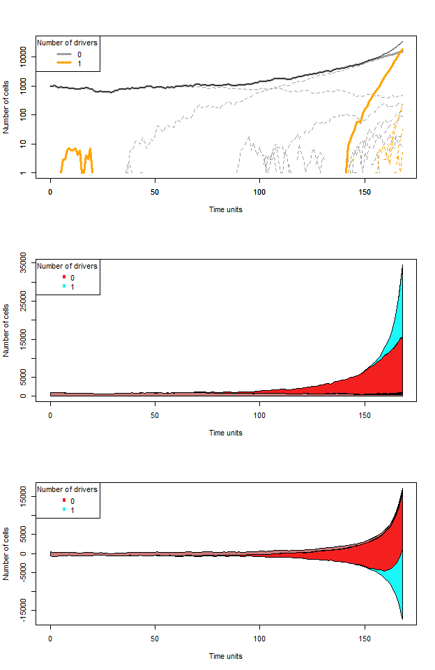

Figure 6.1: Three drivers’ plots of a simulation of Bauer’s model

```r
par(mfrow = c(3, 1))
## First, drivers
plot(b1, type = "line", addtot = TRUE)
plot(b1, type = "stacked")
plot(b1, type = "stream")
```

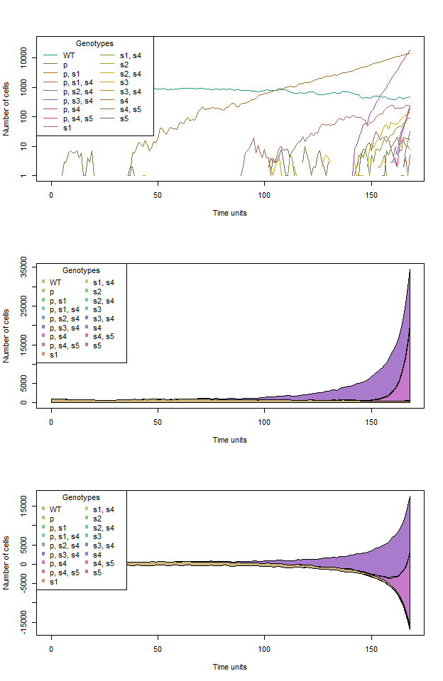

Figure 6.2: Three genotypes’ plots of a simulation of Bauer’s model

```r
par(mfrow = c(3, 1))
## Next, genotypes
plot(b1, show = "genotypes", type = "line")
plot(b1, show = "genotypes", type = "stacked")
plot(b1, show = "genotypes", type = "stream")
```

In this case, probably the stream plots are most helpful. Note, however, that (in contrast to some figures in the literature showing models of clonal expansion) the stream plot (or the stacked plot) does not try to explicitly show parent-descendant relationships, which would hardly be realistically possible in these plots (although the plots of phylogenies in section 8 could be of help).

### 6.5.2 McFarland model with 5000 passengers and 70 drivers

```r
set.seed(678)
nd <- 70
np <- 5000
s <- 0.1
sp <- 1e-3
spp <- -sp/(1 + sp)
mcf1 <- allFitnessEffects(noIntGenes = c(rep(s, nd), rep(spp, np)),
                          drvNames = seq.int(nd))
mcf1s <-  oncoSimulIndiv(mcf1,
                         model = "McFL",
                         mu = 1e-7,
                         detectionProb = "default",
                         detectionSize = NA,
                         detectionDrivers = NA,
                         sampleEvery = 0.025,
                         keepEvery = 8,
                         initSize = 2000,
                         finalTime = 4000,
                         onlyCancer = FALSE)
summary(mcf1s)
##   NumClones TotalPopSize LargestClone MaxNumDrivers MaxDriversLast
## 1       973         2855         2412             3              2
##   NumDriversLargestPop TotalPresentDrivers FinalTime NumIter
## 1                    2                  11   2841.05  117409
##   HittedWallTime HittedMaxTries    errorMF minDMratio minBMratio
## 1          FALSE          FALSE 0.01308528   1694.892   1972.387
##                           OccurringDrivers
## 1 7, 9, 10, 11, 16, 20, 22, 23, 33, 45, 59
```

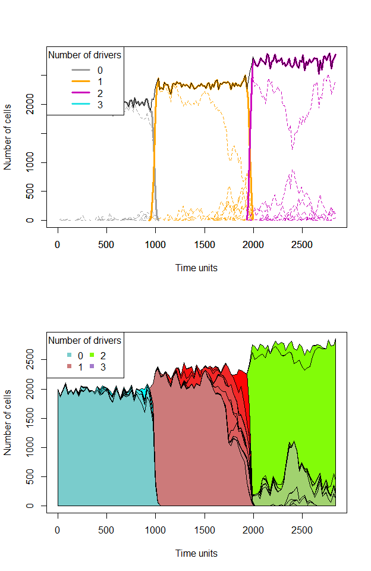

```r
par(mfrow  = c(2, 1))
## I use thinData to make figures smaller and faster
plot(mcf1s, addtot = TRUE, lwdClone = 0.9, log = "",
     thinData = TRUE, thinData.keep = 0.5)
plot(mcf1s, show = "drivers", type = "stacked",
     thinData = TRUE, thinData.keep = 0.3,
     legend.ncols = 2)
```

With the above output (where we see there are over 500 different genotypes) trying to represent the genotypes makes no sense.

### 6.5.3 McFarland model with 50,000 passengers and 70 drivers: clonal competition

The next is too slow (takes a couple of minutes in an i5 laptop) and too big to run in a vignette, because we keep track of over 4000 different clones (which leads to a result object of over 800 MB):

```r
set.seed(123)
nd <- 70
np <- 50000
s <- 0.1
sp <- 1e-4 ## as we have many more passengers
spp <- -sp/(1 + sp)
mcfL <- allFitnessEffects(noIntGenes = c(rep(s, nd), rep(spp, np)),
                          drvNames = seq.int(nd))
mcfLs <-  oncoSimulIndiv(mcfL,
                         model = "McFL",
                         mu = 1e-7,
                         detectionSize = 1e8,
                         detectionDrivers = 100,
                         sampleEvery = 0.02,
                         keepEvery = 2,
                         initSize = 1000,
                         finalTime = 2000,
                         onlyCancer = FALSE)
```

But you can access the pre-stored results and plot them (beware: this object has been trimmed by removing empty passenger rows in the Genotype matrix)

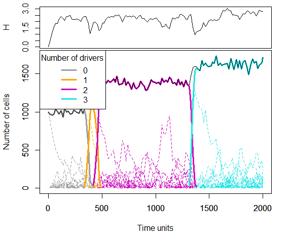

```r
data(mcfLs)
plot(mcfLs, addtot = TRUE, lwdClone = 0.9, log = "",
     thinData = TRUE, thinData.keep = 0.3,
     plotDiversity = TRUE)
```

The argument `plotDiversity = TRUE` asks to show a small plot on top with Shannon’s diversity index.

```r
summary(mcfLs)
##   NumClones TotalPopSize LargestClone MaxNumDrivers MaxDriversLast
## 1      4458         1718          253             3              3
##   NumDriversLargestPop TotalPresentDrivers FinalTime NumIter
## 1                    3                  70      2000  113759
##   HittedWallTime HittedMaxTries    errorMF minDMratio minBMratio
## 1          FALSE          FALSE 0.01921737   184.1019   199.6085
##   OccurringDrivers
## 1   13, 38, 40, 69
## number of passengers per clone
summary(colSums(mcfLs$Genotypes[-(1:70), ]))
##    Min. 1st Qu.  Median    Mean 3rd Qu.    Max.
##   0.000   4.000   6.000   5.673   7.750  13.000
```

Note that we see clonal competition between clones with the same number of drivers (and with different drivers, of course). We will return to this (section 6.5.5).

A stacked plot might be better to show the extent of clonal competition (plotting takes some time —a stream plot reveals similar patterns and is also slower than the line plot). I will aggressively thin the data for this plot so it is faster and smaller (but we miss some of the fine grain, of course):

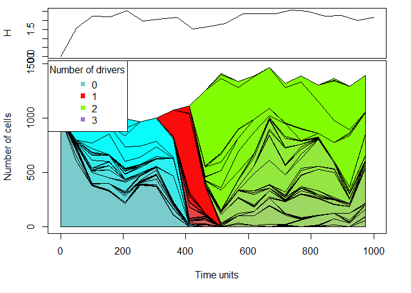

```r
plot(mcfLs, type = "stacked", thinData = TRUE,
     thinData.keep = 0.1,
     plotDiversity = TRUE,
     xlim = c(0, 1000))
```

### 6.5.4 Simulation with a conjunction example

We will use several of the previous examples. Most of them are in file `examplesFitnessEffects`, where they are stored inside a list, with named components (names the same as in the examples above):

```r
data(examplesFitnessEffects)
names(examplesFitnessEffects)
##  [1] "cbn1"   "cbn2"   "smn1"   "xor1"   "fp3"    "fp4m"   "o3"
##  [8] "ofe1"   "ofe2"   "foi1"   "sv"     "svB"    "svB1"   "sv2"
## [15] "sm1"    "e2"     "E3A"    "em"     "fea"    "fbauer" "w"
## [22] "pancr"
```

```r
set.seed(1)
```

We will simulate using the simple CBN-like restrictions of section 3.4.4 with two different models.

```r
data(examplesFitnessEffects)
evalAllGenotypes(examplesFitnessEffects$cbn1, order = FALSE)[1:10, ]
##    Genotype Fitness
## 1         a    1.10
## 2         b    1.10
## 3         c    0.10
## 4         d    1.10
## 5         e    1.10
## 6         g    0.10
## 7      a, b    1.21
## 8      a, c    0.11
## 9      a, d    1.21
## 10     a, e    1.21
sm <-  oncoSimulIndiv(examplesFitnessEffects$cbn1,
                      model = "McFL",
                      mu = 5e-7,
                      detectionSize = 1e8,
                      detectionDrivers = 2,
                      detectionProb = "default",
                      sampleEvery = 0.025,
                      keepEvery = 5,
                      initSize = 2000,
                      onlyCancer = TRUE)
summary(sm)
##   NumClones TotalPopSize LargestClone MaxNumDrivers MaxDriversLast
## 1         4         2635         2014             2              2
##   NumDriversLargestPop TotalPresentDrivers FinalTime NumIter
## 1                    2                   3     372.5   14905
##   HittedWallTime HittedMaxTries    errorMF minDMratio minBMratio
## 1          FALSE          FALSE 0.01265916   314478.5   333333.3
##   OccurringDrivers
## 1          a, b, e
```

```r
set.seed(1234)
evalAllGenotypes(examplesFitnessEffects$cbn1, order = FALSE,
                 model = "Bozic")[1:10, ]
##    Genotype Death_rate
## 1         a       0.90
## 2         b       0.90
## 3         c       1.90
## 4         d       0.90
## 5         e       0.90
## 6         g       1.90
## 7      a, b       0.81
## 8      a, c       1.71
## 9      a, d       0.81
## 10     a, e       0.81
sb <-  oncoSimulIndiv(examplesFitnessEffects$cbn1,
                       model = "Bozic",
                       mu = 5e-6,
                      detectionProb = "default",
                       detectionSize = 1e8,
                       detectionDrivers = 4,
                       sampleEvery = 2,
                       initSize = 2000,
                       onlyCancer = TRUE)
summary(sb)
##   NumClones TotalPopSize LargestClone MaxNumDrivers MaxDriversLast
## 1        12        26655        25030             2              2
##   NumDriversLargestPop TotalPresentDrivers FinalTime NumIter
## 1                    1                   6       550     310
##   HittedWallTime HittedMaxTries errorMF minDMratio minBMratio
## 1          FALSE          FALSE      NA   33333.33   33333.33
##   OccurringDrivers
## 1 a, b, c, d, e, g
```

As usual, we will use several plots here.

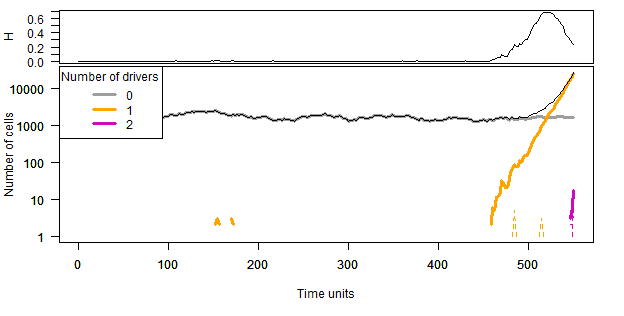

```r
## Show drivers, line plot
par(cex = 0.75, las = 1)
plot(sb,show = "drivers", type = "line", addtot = TRUE,
     plotDiversity = TRUE)
```

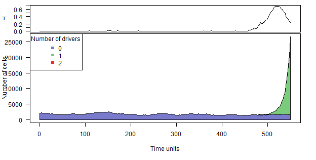

```r
## Drivers, stacked
par(cex = 0.75, las = 1)
plot(sb,show = "drivers", type = "stacked", plotDiversity = TRUE)
```

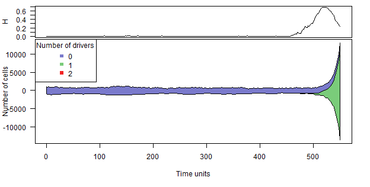

```r
## Drivers, stream
par(cex = 0.75, las = 1)
plot(sb,show = "drivers", type = "stream", plotDiversity = TRUE)
```

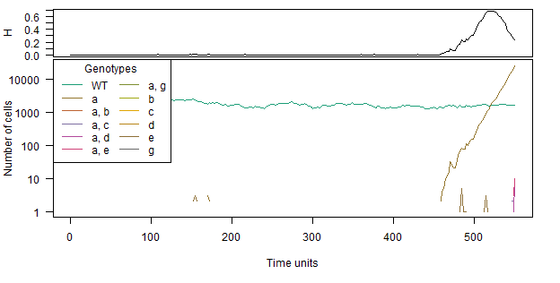

```r
## Genotypes, line plot
par(cex = 0.75, las = 1)
plot(sb,show = "genotypes", type = "line", plotDiversity = TRUE)
```

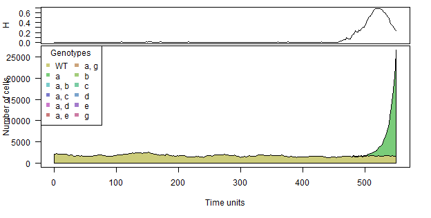

```r
## Genotypes, stacked
par(cex = 0.75, las = 1)
plot(sb,show = "genotypes", type = "stacked", plotDiversity = TRUE)
```

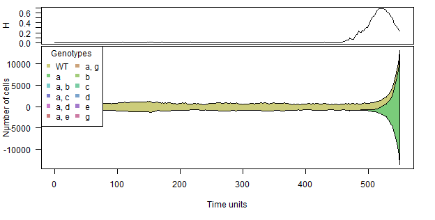

```r
## Genotypes, stream
par(cex = 0.75, las = 1)
plot(sb,show = "genotypes", type = "stream", plotDiversity = TRUE)
```

The above illustrates again that different types of plots can be useful to reveal different patterns in the data. For instance, here, because of the huge relative frequency of one of the clones/genotypes, the stacked and stream plots do not reveal the other clones/genotypes as we cannot use a log-transformed y-axis, even if there are other clones/genotypes present.

### 6.5.5 Simulation with order effects and McFL model

(We use a somewhat large mutation rate than usual, so that the simulation runs quickly.)

```r
set.seed(4321)
tmp <-  oncoSimulIndiv(examplesFitnessEffects[["o3"]],
                       model = "McFL",
                       mu = 5e-5,
                       detectionSize = 1e8,
                       detectionDrivers = 3,
                       sampleEvery = 0.025,
                       max.num.tries = 10,
                       keepEvery = 5,
                       initSize = 2000,
                       finalTime = 6000,
                       onlyCancer = FALSE)
```

We show a stacked and a line plot of the drivers:

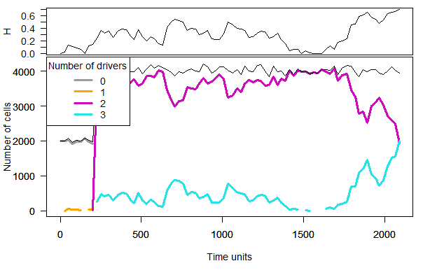

```r
par(las = 1, cex = 0.85)
plot(tmp, addtot = TRUE, log = "", plotDiversity = TRUE,
     thinData = TRUE, thinData.keep = 0.2)
```

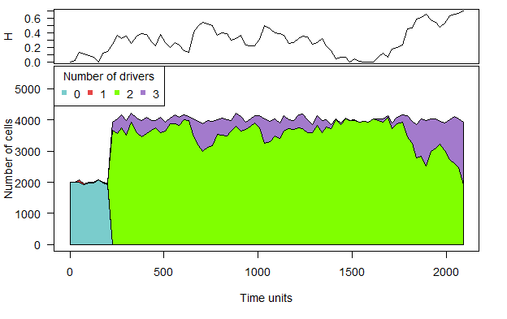

```r
par(las = 1, cex = 0.85)
plot(tmp, type = "stacked", plotDiversity = TRUE,
     ylim = c(0, 5500), legend.ncols = 4,
     thinData = TRUE, thinData.keep = 0.2)
```

```r
evalAllGenotypes(examplesFitnessEffects[["o3"]], addwt = TRUE,
                 order = TRUE)
##     Genotype Fitness
## 1         WT    1.00
## 2          d    1.00
## 3          f    1.00
## 4          m    1.00
## 5      d > f    1.00
## 6      d > m    1.10
## 7      f > d    1.00
## 8      f > m    1.00
## 9      m > d    1.50
## 10     m > f    1.00
## 11 d > f > m    1.54
## 12 d > m > f    1.32
## 13 f > d > m    0.77
## 14 f > m > d    1.50
## 15 m > d > f    1.50
## 16 m > f > d    1.50
```

A few figures could help:

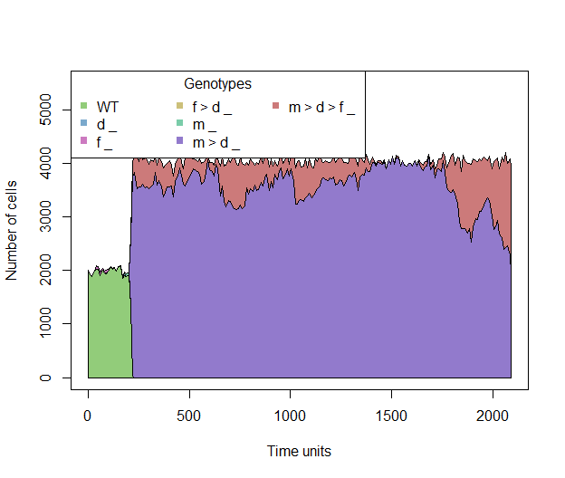

```r
plot(tmp, show = "genotypes", ylim = c(0, 5500), legend.ncols = 3,
     thinData = TRUE, thinData.keep = 0.5)
```

(When reading the figure legends, recall that genotype $x > y\ \_\ z$ is one where a mutation in “x” happened before a mutation in “y”, and there is also a mutation in “z” for which order does not matter. Here, there are no genes for which order does not matter and thus there is nothing after the "_").

In this case, the clones with three drivers end up displacing those with two by the time we stop; moreover, notice how those with one driver never really grow to a large population size, so we basically go from a population with clones with zero drivers to a population made of clones with two or three drivers:

```r
set.seed(15)
tmp <-  oncoSimulIndiv(examplesFitnessEffects[["o3"]],
                       model = "McFL",
                       mu = 5e-5,
                       detectionSize = 1e8,
                       detectionDrivers = 3,
                       sampleEvery = 0.025,
                       max.num.tries = 10,
                       keepEvery = 5,
                       initSize = 2000,
                       finalTime = 20000,
                       onlyCancer = FALSE,
                       extraTime = 1500)
tmp
##
## Individual OncoSimul trajectory with call:
##  oncoSimulIndiv(fp = examplesFitnessEffects[["o3"]], model = "McFL",
##     mu = 5e-05, detectionSize = 1e+08, detectionDrivers = 3,
##     sampleEvery = 0.025, initSize = 2000, keepEvery = 5, extraTime = 1500,
##     finalTime = 20000, onlyCancer = FALSE, max.num.tries = 10)
##
##   NumClones TotalPopSize LargestClone MaxNumDrivers MaxDriversLast
## 1         7         4079         4079             3              3
##   NumDriversLargestPop TotalPresentDrivers FinalTime NumIter
## 1                    3                   3  7178.375  288927
##   HittedWallTime HittedMaxTries    errorMF minDMratio minBMratio
## 1          FALSE          FALSE 0.01343206   6253.799   6666.667
##   OccurringDrivers
## 1          d, f, m
##
## Final population composition:
##       Genotype    N
## 1           _     0
## 2         d _     0
## 3     d > m _     0
## 4         f _     0
## 5         m _     0
## 6     m > d _     0
## 7 m > d > f _  4079
```

use a drivers plot:

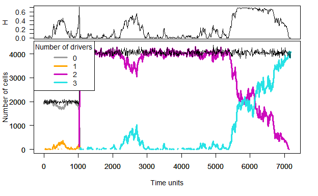

```r
par(las = 1, cex = 0.85)
plot(tmp, addtot = TRUE, log = "", plotDiversity = TRUE,
     thinData = TRUE, thinData.keep = 0.5)
```

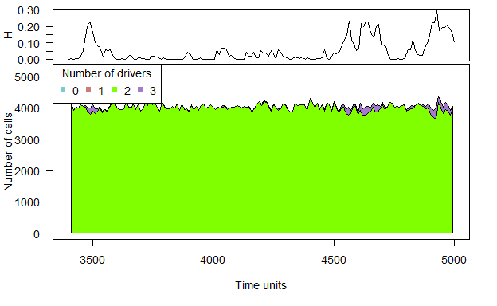

```r
par(las = 1, cex = 0.85)
plot(tmp, type = "stacked", plotDiversity = TRUE,
     legend.ncols = 4, ylim = c(0, 5200), xlim = c(3400, 5000),
     thinData = TRUE, thinData.keep = 0.5)
```

Now show the genotypes explicitly:

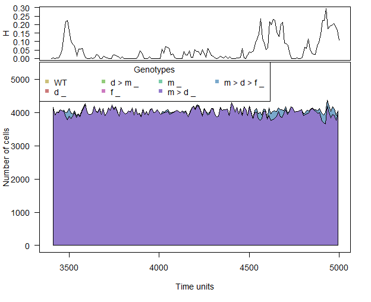

```r
## Improve telling apart the most abundant
## genotypes by sorting colors
## differently via breakSortColors
## Modify ncols of legend, so it is legible by not overlapping
## with plot
par(las = 1, cex = 0.85)
plot(tmp, show = "genotypes", breakSortColors = "distave",
     plotDiversity = TRUE, legend.ncols = 4,
     ylim = c(0, 5300), xlim = c(3400, 5000),
     thinData = TRUE, thinData.keep = 0.5)
```

As before, the argument `plotDiversity = TRUE` asks to show a small plot on top with Shannon’s diversity index. Here, as before, the quick clonal expansion of the clone with two drivers leads to a sudden drop in diversity (for a while, the population is made virtually of a single clone). Note, however, that compared to section 6.5.3, we are modeling here a scenario with very few genes, and correspondingly very few possible genotypes, and thus it is not strange that we observe very little diversity.

(We have used `extraTime` to continue the simulation well past the point of detection, here specified as three drivers. Instead of specifying `extraTime` we can set the `detectionDrivers` value to a number larger than the number of existing possible drivers, and the simulation will run until `finalTime` if `onlyCancer = FALSE`.)

## 6.6 Interactive graphics

It is possible to create interactive stacked area and stream plots using the *streamgraph* package, available from https://github.com/hrbrmstr/streamgraph. However, that package is not available as a CRAN or BioConductor package, and thus we cannot depend on it for this vignette (or this package). You can, however, paste the code below and make it run locally.

Before calling the `streamgraph` function, though, we need to convert the data from the original format in which it is stored into “long format”. A simple convenience function is provided as `OncoSimulWide2Long` in *OncoSimulR*.

As an example, we will use the data we generated above for section 6.5.1.

```r
## Convert the data
lb1 <- OncoSimulWide2Long(b1)

## Install the streamgraph package from GitHub and load
library(devtools)
devtools::install_github("hrbrmstr/streamgraph")
library(streamgraph)

## Stream plot for Genotypes
sg_legend(streamgraph(lb1, Genotype, Y, Time, scale = "continuous"),
              show=TRUE, label="Genotype: ")

## Staked area plot and we use the pipe
streamgraph(lb1, Genotype, Y, Time, scale = "continuous",
            offset = "zero") %>%
    sg_legend(show=TRUE, label="Genotype: ")
```

## 6.7 Multiple initial mutants: starting the simulation from arbitrary configurations

You can specify the population composition when you start the simulation: in other words, you can use multiple initial mutants. Simply pass a vector to `initMutant` and a vector of the same length to `initSize`: the first are the genotypes/clones, the second the population sizes of the corresponding genotypes/clones.

(It often makes no sense to start the simulation with genotypes with birth rate of 0: you can try it, but you will be told about it.)

Two examples.

```r
r2 <- rfitness(6)
## Make sure these always viable for interesting stuff
r2[2, 7] <- 1 + runif(1) # A
r2[4, 7] <- 1 + runif(1) # C
r2[8, 7] <- 1 + runif(1) # A, B
o2 <- allFitnessEffects(genotFitness = r2)
ag <- evalAllGenotypes(o2)

out1 <- oncoSimulIndiv(o2, initMutant = c("A", "C"),
                       initSize = c(100, 200),
                       onlyCancer = FALSE,
                       finalTime = 200)
```

No WT, nor any other genotypes with a single mutation (except “A” and “C”) would thus be possible either (it is impossible to obtain, say, a “B” if there are no WT).

We can do something similar with the frequency-dependent functionality (section 10):

```r
gffd0 <- data.frame(
    Genotype = c(
        "A", "A, B",
        "C", "C, D", "C, E"),
    Fitness = c(
        "1.3",
        "1.4",
        "1.4",
        "1.1 + 0.7*((f_A + f_A_B) > 0.3)",
        "1.2 + sqrt(f_A + f_C + f_C_D)"))

afd0 <- allFitnessEffects(genotFitness = gffd0,
                          frequencyDependentFitness = TRUE)
## frequencyType set to 'auto'

sp <- 1:5
names(sp) <- c("A", "C", "A, B", "C, D", "C, E")
eag0 <- evalAllGenotypes(afd0, spPopSizes = sp)

os0 <- oncoSimulIndiv(afd0,
                      initMutant = c("A", "C"),
                      finalTime = 20, initSize = c(1e4, 1e5),
                      onlyCancer = FALSE, model = "McFLD")
```

## 6.8 Multispecies simulations

Since we can use arbitrary initial populations to start the simulation (section 6.7) and we can use arbitrary fitness specifications, you can run multi-species simulations using a simple trick.

Suppose you want to use a two species simulation, where the first species has two loci and the second three loci. This is a possible procedure:

- Create a genotype of total length (1 + 2) + (1 + 3).
- The first locus in each set we will use as the “species indicator”.
- Thus, Species A will use loci 1, 2, 3 and Species B loci 4 to 7.
- Make all genotype combinations where loci from different species are mutated lethal (e.g., a genotype with loci 2 and 5 mutated is not viable).
- Now you can start the simulation from the “WT of each species”: the initMutants will have genotypes with only loci 1 or loci 4 mutated.

Of course, you can extend the scheme above to arbitrary numbers of species.

Let’s give several examples.

We use a capital letter for the “species indicator locus” and name each of the species-specific loci with the lower case and a number. We then ameliorate the leakage issue by making mutation to “A” or “B” tiny (though there is still leakage from, say, “A” to “A, b1”).

```r
mspec <- data.frame(
    Genotype = c("A",
                 "A, a1", "A, a2", "A, a1, a2",
                 "B",
                 "B, b1", "B, b2", "B, b3",
                 "B, b1, b2", "B, b1, b3", "B, b1, b2, b3"),
    Fitness = 1 + runif(11)
)
fmspec <- allFitnessEffects(genotFitness = mspec)
## Warning in allGenotypes_to_matrix(x, frequencyDependentFitness): No
## WT genotype. Setting its fitness to 1.
afmspec <- evalAllGenotypes(fmspec)

## Show only viable ones
afmspec[afmspec$Fitness >= 1, ]
##         Genotype  Fitness
## 1              A 1.373084
## 4              B 1.244635
## 8          A, a1 1.527541
## 9          A, a2 1.222121
## 23         B, b1 1.882429
## 24         B, b2 1.635225
## 25         B, b3 1.417049
## 29     A, a1, a2 1.443343
## 60     B, b1, b2 1.748318
## 61     B, b1, b3 1.704849
## 98 B, b1, b2, b3 1.667957

muv <- c(1e-10, rep(1e-5, 2), 1e-10, rep(1e-5, 3))
names(muv) <- c("A", paste0("a", 1:2), "B", paste0("b", 1:3))

out1 <- oncoSimulIndiv(fmspec, initMutant = c("A", "B"),
                       initSize = c(100, 200),
                       mu = muv,
                       onlyCancer = FALSE,
                       finalTime = 200)
```

We can do something similar with the frequency-dependent-fitness functionality. (We use a somewhat silly specification, so that checking equations is easy)

```r
mspecF <- data.frame(
    Genotype = c("A",
                 "A, a1", "A, a2", "A, a1, a2",
                 "B",
                 "B, b1", "B, b2", "B, b3",
                 "B, b1, b2", "B, b1, b3", "B, b1, b2, b3"),
    Fitness = c("1 + f_A_a1",
                "1 + f_A_a2",
                "1 + f_A_a1_a2",
                "1 + f_B",
                "1 + f_B_b1",
                "1 + f_B_b2",
                "1 + f_B_b3",
                "1 + f_B_b1_b2",
                "1 + f_B_b1_b3",
                "1 + f_B_b1_b2_b3",
                "1 + f_A")
)
fmspecF <- allFitnessEffects(genotFitness = mspecF,
                             frequencyDependentFitness = TRUE)
## frequencyType set to 'auto'
## Remeber, spPopSizes correspond to the genotypes
## shown in
fmspecF$full_FDF_spec
##    A a1 a2 B b1 b2 b3 Genotype_as_numbers Genotype_as_letters
## 1  1  0  0 0  0  0  0                   1                   A
## 2  0  0  0 1  0  0  0                   4                   B
## 3  1  1  0 0  0  0  0                1, 2               A, a1
## 4  1  0  1 0  0  0  0                1, 3               A, a2
## 5  0  0  0 1  1  0  0                4, 5               B, b1
## 6  0  0  0 1  0  1  0                4, 6               B, b2
## 7  0  0  0 1  0  0  1                4, 7               B, b3
## 8  1  1  1 0  0  0  0             1, 2, 3           A, a1, a2
## 9  0  0  0 1  1  1  0             4, 5, 6           B, b1, b2
## 10 0  0  0 1  1  0  1             4, 5, 7           B, b1, b3
## 11 0  0  0 1  1  1  1          4, 5, 6, 7       B, b1, b2, b3
##    Genotype_as_fvars Fitness_as_fvars Fitness_as_letters
## 1                f_1        1 + f_1_2         1 + f_A_a1
## 2                f_4        1 + f_4_5         1 + f_B_b1
## 3              f_1_2        1 + f_1_3         1 + f_A_a2
## 4              f_1_3      1 + f_1_2_3      1 + f_A_a1_a2
## 5              f_4_5        1 + f_4_6         1 + f_B_b2
## 6              f_4_6        1 + f_4_7         1 + f_B_b3
## 7              f_4_7      1 + f_4_5_6      1 + f_B_b1_b2
## 8            f_1_2_3          1 + f_4            1 + f_B
## 9            f_4_5_6      1 + f_4_5_7      1 + f_B_b1_b3
## 10           f_4_5_7    1 + f_4_5_6_7   1 + f_B_b1_b2_b3
## 11         f_4_5_6_7          1 + f_1            1 + f_A
## in exactly that order if it is unnamed.

afmspecF <- evalAllGenotypes(fmspecF,
                             spPopSizes = 1:11)
## Warning in match_spPopSizes(spPopSizes, fmEffects): spPopSizes
## unnamed: cannot check genotype names.

## Alternatively, pass a named vector, which is the recommended approach

spp <- 1:11
names(spp) <- c("A","B",
                "A, a1", "A, a2",
                "B, b1", "B, b2", "B, b3",
                "A, a1, a2",
                "B, b1, b2", "B, b1, b3", "B, b1, b2, b3")

afmspecF <- evalAllGenotypes(fmspecF,
                             spPopSizes = spp)


## Show only viable ones
afmspecF[afmspecF$Fitness >= 1, ]
##         Genotype  Fitness
## 2              A 1.045455
## 5              B 1.075758
## 9          A, a1 1.060606
## 10         A, a2 1.121212
## 24         B, b1 1.090909
## 25         B, b2 1.106061
## 26         B, b3 1.136364
## 30     A, a1, a2 1.030303
## 61     B, b1, b2 1.151515
## 62     B, b1, b3 1.166667
## 99 B, b1, b2, b3 1.015152

## Expected values of fitness
exv <- 1 + c(3, 5, 4, 8, 6, 7, 9, 2, 10, 11, 1)/sum(1:11)
stopifnot(isTRUE(all.equal(exv, afmspecF[afmspecF$Fitness >= 1, ]$Fitness)))

muv <- c(1e-10, rep(1e-5, 2), 1e-10, rep(1e-5, 3))
names(muv) <- c("A", paste0("a", 1:2), "B", paste0("b", 1:3))

out1 <- oncoSimulIndiv(fmspecF, initMutant = c("A", "B"),
                       initSize = c(1e4, 1e5),
                       mu = muv,
                       finalTime = 20,
                       model = "McFLD",
                       onlyCancer = FALSE)
## Init Mutant with birth == 1.0
## Init Mutant with birth == 1.0
```

Some further examples are given below, as in 10.4.2.

# 7 Sampling multiple simulations

Often, you will want to simulate multiple runs of the same scenario, and then obtain the matrix of runs by mutations (a matrix of individuals/samples by genes or, equivalently, a vector of “genotypes”), and do something with them. OncoSimulR offers several ways of doing this.

The key function here is `samplePop`, either called explicitly after `oncoSimulPop` (or `oncoSimulIndiv`), or implicitly as part of a call to `oncoSimulSample`. With `samplePop` you can use **single cell** or **whole tumor** sampling (for details see the help of `samplePop`). Depending on how the simulations were conducted, you might also sample at different times, or as a function of population sizes. A major difference between procedures has to do with whether or not you want to keep the complete history of the simulations.

**You want to keep the complete history of population sizes of clones during the simulations**. You will simulate using:

- `oncoSimulIndiv` repeatedly (maybe within `mclapply`, to parallelize the run).
- `oncoSimulPop`. `oncoSimulPop` is basically a thin wrapper around `oncoSimulIndiv` that uses `mclapply`.

In both cases, you specify the conditions for ending the simulations (as explained in 6.3). Then, you use function `samplePop` to obtain the matrix of samples by mutations.

**You do not want to keep the complete history of population sizes of clones during the simulations**. You will simulate using:

- `oncoSimulIndiv` repeatedly, with argument `keepEvery = NA`.
- `oncoSimulPop`, with argument `keepEvery = NA`.

  In both cases you specify the conditions for ending the simulations (as explained in 6.3). Then, you use function `samplePop`.
- `oncoSimulSample`, specifying the conditions for ending the simulations (as explained in 6.3). In this case, you will not use `samplePop`, as that is implicitly called by `oncoSimulSample`. The output is directly the matrix (and a little bit of summary from each run), and during the simulation it only stores one time point.

Why the difference between the above cases? If you keep the complete history of population sizes, you can take samples at any of the times between the beginning and the end of the simulations. If you do not keep the history, you can only sample at the time the simulation exited (see section 15.2). Why would you want to use the second route? If we are only interested in the final matrix of individuals by mutations, keeping the complete history above is wasteful because we store fully all of the simulations (for example in the call to `oncoSimulPop`) and then sample (in the call to `samplePop`). Further criteria to use when choosing between sampling procedures is whether you need `detectionSize` and `detectionDrivers` do differ between simulations: if you use `oncoSimulPop` the arguments for `detectionSize` and `detectionDrivers` must be the same for all simulations but this is not the case for `oncoSimulSample`. See further comments in 7.2. Finally, parallelized execution is available for `oncoSimulPop` but, by design, not for `oncoSimulSample`.

The following are a few examples. First we run `oncoSimulPop` to obtain 4 simulations and in the last line we sample from them:

```r
pancrPop <- oncoSimulPop(4, pancr,
                         detectionSize = 1e7,
                         keepEvery = 10,
                         mc.cores = 2)
## You are running Windows. Setting mc.cores = 1

summary(pancrPop)
##   NumClones TotalPopSize LargestClone MaxNumDrivers MaxDriversLast
## 1        12     10377737     10157594             0              0
## 2        15     10166529      7200127             0              0
## 3        11     10645330     10499346             0              0
## 4         9     10311904     10168310             0              0
##   NumDriversLargestPop TotalPresentDrivers FinalTime NumIter
## 1                    0                   0       309     998
## 2                    0                   0      1396    1968
## 3                    0                   0      2042    2739
## 4                    0                   0      1280    1932
##   HittedWallTime HittedMaxTries errorMF minDMratio minBMratio
## 1          FALSE          FALSE      NA   142857.1   142857.1
## 2          FALSE          FALSE      NA   142857.1   142857.1
## 3          FALSE          FALSE      NA   142857.1   142857.1
## 4          FALSE          FALSE      NA   142857.1   142857.1
##   OccurringDrivers
## 1
## 2
## 3
## 4
samplePop(pancrPop)
##
##  Subjects by Genes matrix of 4 subjects and 7 genes.
##      CDNK2A KRAS MLL3 PXDN SMAD4 TGFBR2 TP53
## [1,]      0    1    0    0     0      0    0
## [2,]      0    1    0    0     0      0    0
## [3,]      0    1    0    0     0      0    0
## [4,]      0    1    0    0     0      0    0
```

Now a simple multiple call to `oncoSimulIndiv` wrapped inside `mclapply`; this is basically the same we just did above. We set the class of the object to allow direct usage of `samplePop`. (Note: in Windows `mc.cores > 1` is not supported, so for the vignette to run in Windows, Linux, and Mac we explicitly set it here in the call to `mclapply`. For regular usage, you will not need to do this; just use whatever is appropriate for your operating system and number of cores. As well, we do not need any of this with `oncoSimulPop` because the code inside `oncoSimulPop` already takes care of setting `mc.cores` to 1 in Windows).

```r
library(parallel)

if(.Platform$OS.type == "windows") {
    mc.cores <- 1
} else {
    mc.cores <- 2
}

p2 <- mclapply(1:4, function(x) oncoSimulIndiv(pancr,
                                               detectionSize = 1e7,
                                               keepEvery = 10),
                                               mc.cores = mc.cores)
class(p2) <- "oncosimulpop"
samplePop(p2)
##
##  Subjects by Genes matrix of 4 subjects and 7 genes.
##      CDNK2A KRAS MLL3 PXDN SMAD4 TGFBR2 TP53
## [1,]      0    1    0    0     0      0    0
## [2,]      0    1    0    0     0      0    0
## [3,]      0    1    0    0     0      0    0
## [4,]      0    1    0    0     0      0    0
```

Above, we have kept the complete history of the simulations as you can check by doing, for instance

```r
tail(pancrPop[[1]]$pops.by.time)
##       [,1] [,2]   [,3] [,4] [,5] [,6] [,7]     [,8]  [,9] [,10]
## [27,]  260  515      3    0    0    0    0    74333     0     0
## [28,]  270  567     57    0    0    0    0   205875     0     0
## [29,]  280  649    384    0    0    0    0   557755    23     1
## [30,]  290  754   2517    0    0    0    0  1511068   271     0
## [31,]  300  908  18439    8    0    2    0  4112116  2088     7
## [32,]  309  840 122978   95    9    0    3 10157594 12103     8
##       [,11] [,12] [,13]
## [27,]     0     0     0
## [28,]     2     0     1
## [29,]   178     1     5
## [30,]  1369     2   158
## [31,] 11432     6  1254
## [32,] 75928     5  8174
```

If we were not interested in the complete history of simulations we could have done instead (note the argument `keepEvery = NA`)

```r
pancrPopNH <- oncoSimulPop(4, pancr,
                           detectionSize = 1e7,
                           keepEvery = NA,
                           mc.cores = 2)
## You are running Windows. Setting mc.cores = 1

summary(pancrPopNH)
##   NumClones TotalPopSize LargestClone MaxNumDrivers MaxDriversLast
## 1         8     10295517     10272077             0              0
## 2        11     10441890      9948283             0              0
## 3         9     10939988     10888963             0              0
## 4        10     10287820      9965370             0              0
##   NumDriversLargestPop TotalPresentDrivers FinalTime NumIter
## 1                    0                   0      2210    2941
## 2                    0                   0      1987    2316
## 3                    0                   0       211     892
## 4                    0                   0      1074    1753
##   HittedWallTime HittedMaxTries errorMF minDMratio minBMratio
## 1          FALSE          FALSE      NA   142857.1   142857.1
## 2          FALSE          FALSE      NA   142857.1   142857.1
## 3          FALSE          FALSE      NA   142857.1   142857.1
## 4          FALSE          FALSE      NA   142857.1   142857.1
##   OccurringDrivers
## 1
## 2
## 3
## 4
samplePop(pancrPopNH)
##
##  Subjects by Genes matrix of 4 subjects and 7 genes.
##      CDNK2A KRAS MLL3 PXDN SMAD4 TGFBR2 TP53
## [1,]      0    1    0    0     0      0    0
## [2,]      0    1    0    0     0      0    1
## [3,]      0    1    0    0     0      0    0
## [4,]      0    1    0    0     0      0    0
```

which only keeps the very last sample:

```r
pancrPopNH[[1]]$pops.by.time
##      [,1]  [,2] [,3]     [,4] [,5] [,6] [,7] [,8] [,9]
## [1,] 2210 11505  563 10272077 4170   11 5022   10 2159
```

Or we could have used `oncoSimulSample`:

```r
pancrSamp <- oncoSimulSample(4, pancr)
## Successfully sampled 4 individuals
##
##  Subjects by Genes matrix of 4 subjects and 7 genes.
pancrSamp$popSamp
##      CDNK2A KRAS MLL3 PXDN SMAD4 TGFBR2 TP53
## [1,]      0    1    0    0     0      0    0
## [2,]      0    1    0    0     0      0    0
## [3,]      0    1    0    0     0      0    0
## [4,]      0    1    0    0     0      0    0
```

Again, why the above differences? If we are only interested in the final matrix of populations by mutations, keeping the complete history the above is wasteful, because we store fully all of the simulations (in the call to `oncoSimulPop`) and then sample (in the call to `samplePop`).

## 7.1 Whole-tumor and single-cell sampling, and do we always want to sample?

`samplePop` is designed to emulate the process of obtaining a sample from a (set of) “patient(s)”. But there is no need to sample. The history of the population, with a granularity that is controlled by argument `keepEvery`, is kept in the matrix `pops.by.time` which contains the number of cells of every clone at every sampling point (see further details in 15.2). This is the information used in the plots that show the trajectory of a simulation: the plots that show the change in genotype or driver abundance over time (see section 6.4 and examples mentioned there).

Regardless of whether and how you plot the information in `pops.by.time`, you can also sample one or multiple simulations using `samplePop`. In **whole-tumor** sampling the resolution is the whole tumor (or the whole population). Thus, a key argument is `thresholdWhole`, the threshold for detecting a mutation: a gene is considered mutated if it is altered in at least “thresholdWhole” proportion of the cells in that simulation (at a particular time point). This of course means that your “sampled genotype” might not correspond to any existing genotype because we are summing over all cells in the population. For instance, suppose that at the time we take the sample there are only two clones in the population, one clone with a frequency of 0.4 that has gene A mutated, and a second clone one with a frequency of 0.6 that has gene B mutated. If you set `thresholdWhole` to values $\leq 0.4$ the sampled genotype will show both A and B mutated. **Single-cell** sampling is provided as an option in contrast to whole-tumor sampling. Here any sampled genotype will correspond to an existing genotype as you are sampling with single-cell resolution.

When `samplePop` is run on a set of simulated data of, say, 100 simulated trajectories (100 “subjects”), it will produce a matrix with 100 rows (100 “subjects”). But if it makes sense in the context of your problem (e.g., multiple samples per patient?) you can of course run `samplePop` repeatedly.

## 7.2 Differences between “samplePop” and “oncoSimulSample”

`samplePop` provides two sampling times: “last” and “uniform”. It also allows you to sample at the first sample time(s) at which the population(s) reaches a given size, which can be either the same or different for each simulation (with argument `popSizeSample`). “last” means to sample each individual in the very last time period of the simulation. “uniform” means sampling each individual at a time chosen uniformly from all the times recorded in the simulation between the time when the first driver appeared and the final time period. “unif” means that it is almost sure that different individuals will be sampled at different times. “last” does not guarantee that different individuals will be sampled at the same time unit, only that all will be sampled in the last time unit of their simulation.

An advantage of `oncoSimulSample` is that we can specify arbitrary sampling schemes, just by passing the appropriate vector `detectionSize` and `detectionDrivers`. A disadvantage is that if we change the stopping conditions we can not just resample the data, but we need to run it again.

There is no difference between `oncoSimulSample` and `oncoSimulPop` + `samplePop` in terms of the `typeSample` argument (whole tumor or single cell).

Finally, there are some additional differences between the two functions. `oncoSimulPop` can run parallelized (it uses `mclapply`). This is not done with `oncoSimulSample` because this function is designed for simulation experiments where you want to examine many different scenarios simultaneously. Thus, we provide additional stopping criteria (`max.wall.time.total` and `max.num.tries.total`) to determine whether to continue running the simulations, that bounds the total running time of all the simulations in a call to `oncoSimulSample`. And, if you are running multiple different scenarios, you might want to make multiple, separate, independent calls (e.g., from different R processes) to `oncoSimulSample`, instead of relying in `mclapply`, since this is likely to lead to better usage of multiple cores/CPUs if you are examining a large number of different scenarios.

# 8 Showing the genealogical relationships of clones

If you run simulations with `keepPhylog = TRUE`, the simulations keep track of when every clone is generated, and that will allow us to see the parent-child relationships between clones. (This is disabled by default).

Let us re-run a previous example:

```r
set.seed(15)
tmp <-  oncoSimulIndiv(examplesFitnessEffects[["o3"]],
                       model = "McFL",
                       mu = 5e-5,
                       detectionSize = 1e8,
                       detectionDrivers = 3,
                       sampleEvery = 0.025,
                       max.num.tries = 10,
                       keepEvery = 5,
                       initSize = 2000,
                       finalTime = 20000,
                       onlyCancer = FALSE,
                       extraTime = 1500,
                       keepPhylog = TRUE)
tmp
##
## Individual OncoSimul trajectory with call:
##  oncoSimulIndiv(fp = examplesFitnessEffects[["o3"]], model = "McFL",
##     mu = 5e-05, detectionSize = 1e+08, detectionDrivers = 3,
##     sampleEvery = 0.025, initSize = 2000, keepEvery = 5, extraTime = 1500,
##     finalTime = 20000, onlyCancer = FALSE, keepPhylog = TRUE,
##     max.num.tries = 10)
##
##   NumClones TotalPopSize LargestClone MaxNumDrivers MaxDriversLast
## 1         7         4079         4079             3              3
##   NumDriversLargestPop TotalPresentDrivers FinalTime NumIter
## 1                    3                   3  7178.375  288927
##   HittedWallTime HittedMaxTries    errorMF minDMratio minBMratio
## 1          FALSE          FALSE 0.01343206   6253.799   6666.667
##   OccurringDrivers
## 1          d, f, m
##
## Final population composition:
##       Genotype    N
## 1           _     0
## 2         d _     0
## 3     d > m _     0
## 4         f _     0
## 5         m _     0
## 6     m > d _     0
## 7 m > d > f _  4079
```

We can plot the parent-child relationships[^14] of every clone ever created (with fitness larger than 0 —clones without viability are never shown):

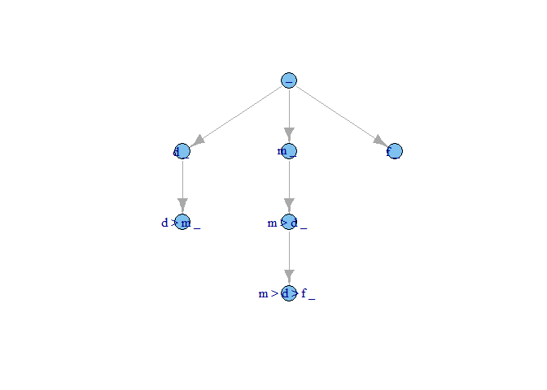

```r
plotClonePhylog(tmp, N = 0)
```

However, we often only want to show clones that exist (have number of cells $>0$) at a certain time (while of course showing all of their ancestors, even if those are now extinct —i.e., regardless of their current numbers).

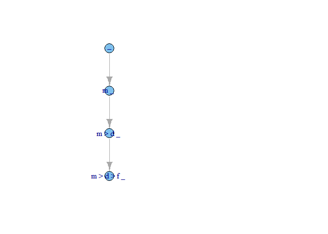

```r
plotClonePhylog(tmp, N = 1)
```

If we set `keepEvents = TRUE` the arrows show how many times each clone appeared:

(The next can take a while)

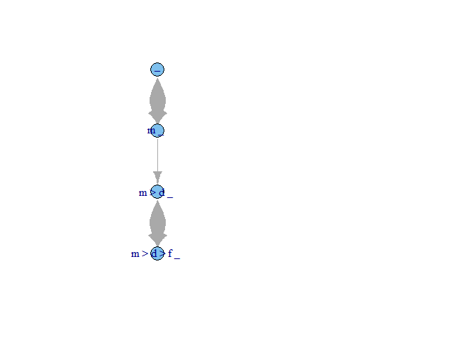

```r
plotClonePhylog(tmp, N = 1, keepEvents = TRUE)
```

And we can show the plot so that the vertical axis is proportional to time (though you might see overlap of nodes if a child node appeared shortly after the parent):

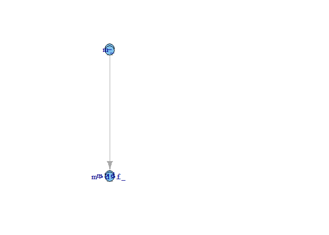

```r
plotClonePhylog(tmp, N = 1, timeEvents = TRUE)
```

We can obtain the adjacency matrix doing

```r
get.adjacency(plotClonePhylog(tmp, N = 1, returnGraph = TRUE))
## 4 x 4 sparse Matrix of class "dgCMatrix"
##               _  m _  m > d _  m > d > f _
##  _             .    1        .            .
## m _            .    .        1            .
## m > d _        .    .        .            1
## m > d > f _    .    .        .            .
```

We can see another example here:

```r
set.seed(456)
mcf1s <-  oncoSimulIndiv(mcf1,
                         model = "McFL",
                         mu = 1e-7,
                         detectionSize = 1e8,
                         detectionDrivers = 100,
                         sampleEvery = 0.025,
                         keepEvery = 2,
                         initSize = 2000,
                         finalTime = 1000,
                         onlyCancer = FALSE,
                         keepPhylog = TRUE)
```

Showing only clones that exist at the end of the simulation (and all their parents):

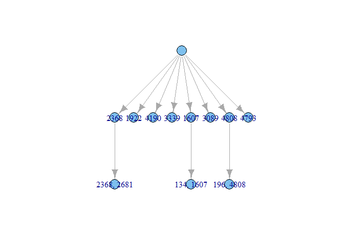

```r
plotClonePhylog(mcf1s, N = 1)
```

Notice that the labels here do not have a "_", since there were no order effects in fitness. However, the labels show the genes that are mutated, just as before.

Similar, but with vertical axis proportional to time:

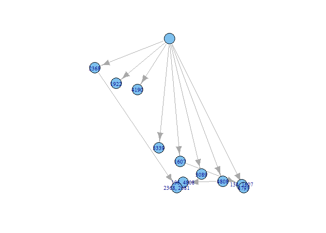

```r
par(cex = 0.7)
plotClonePhylog(mcf1s, N = 1, timeEvents = TRUE)
```

What about those that existed in the last 200 time units?

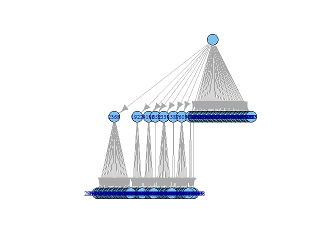

```r
par(cex = 0.7)
plotClonePhylog(mcf1s, N = 1, t = c(800, 1000))
```

And try now to show also when the clones appeared (we restrict the time to between 900 and 1000, to avoid too much clutter):

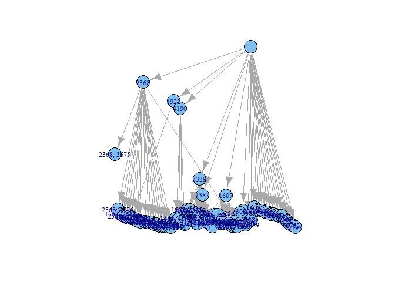

```r
par(cex = 0.7)
plotClonePhylog(mcf1s, N = 1, t = c(900, 1000), timeEvents = TRUE)
```

(By playing with `t`, it should be possible to obtain animations of the phylogeny. We will not pursue it here.)

If the previous graph seems cluttered, we can represent it in a different way by calling *igraph* directly after storing the graph and using the default layout:

```r
g1 <- plotClonePhylog(mcf1s, N = 1, t = c(900, 1000),
                      returnGraph = TRUE)
```

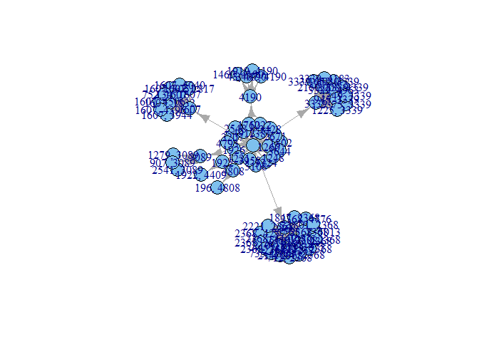

```r
plot(g1)
```

which might be easier to show complex relationships or identify central or key clones.

It is of course quite possible that, especially if we consider few genes, the parent-child relationships will form a network, not a tree, as the same child node can have multiple parents. You can play with this example, modified from one we saw before (section 3.4.6):

```r
op <- par(ask = TRUE)
while(TRUE) {
    tmp <- oncoSimulIndiv(smn1, model = "McFL",
                          mu = 5e-5, finalTime = 500,
                          detectionDrivers = 3,
                          onlyCancer = FALSE,
                          initSize = 1000, keepPhylog = TRUE)
    plotClonePhylog(tmp, N = 0)
}
par(op)
```

## 8.1 Parent-child relationships from multiple runs

If you use `oncoSimulPop` you can store and plot the “phylogenies” of the different runs:

```r
oi <- allFitnessEffects(orderEffects =
               c("F > D" = -0.3, "D > F" = 0.4),
               noIntGenes = rexp(5, 10),
                          geneToModule =
                              c("F" = "f1, f2, f3",
                                "D" = "d1, d2") )
oiI1 <- oncoSimulIndiv(oi, model = "Exp")
oiP1 <- oncoSimulPop(4, oi,
                     keepEvery = 10,
                     mc.cores = 2,
                     keepPhylog = TRUE)
## You are running Windows. Setting mc.cores = 1
```

We will plot the first two:

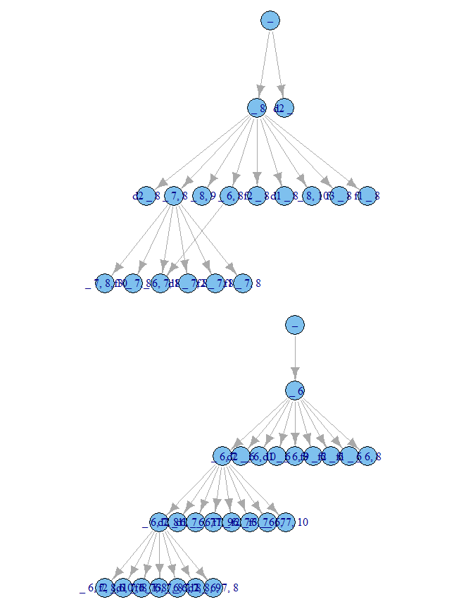

```r
op <- par(mar = rep(0, 4), mfrow = c(2, 1))
plotClonePhylog(oiP1[[1]])
plotClonePhylog(oiP1[[2]])
```

```r
par(op)
```

This is so far disabled in function `oncoSimulSample`, since that function is optimized for other uses. This might change in the future.